# Homework 4 - Working with large datasets

Sophie Shan

02/15/2024

```r
#load libraries
library(data.table)
library(tidyverse)
```

```r
library(ggplot2)
library(microbenchmark)
library(Matrix)
```

# Question 1 - benchmark data.table’s grouping on real data

Download the merged College Scorecard data from (2009-2016) from here: https://www.dropbox.com/s/ex0u45rlrjr6h7e/Scorecard_2009-2016.csv?dl=0

This file is the final merged form of the original data that was discussed in class, using the shell operation. Please use this file for the subsequent questions. Excluding the header, there should be 67,418 rows in this file.

```r
#load the data
scores <- fread("/Users/sophshan/Desktop/OneDrive - University of North Carolina at Chapel Hill/UNC/Spring 2024/BIOS 735/Homework Assignments/HW4/Scorecard_2009-2016.csv")

#check dimensions
dim(scores)
```

```
## [1] 67418  1977
```

In class we performed some simple subsetting and grouping operations. The lecture notes use a previous version of the dataset, and since they were compiled, `CONTROL` is now integer valued, and the `TUITFTE` and `SAT_AVG` columns will need to be coerced to a numeric using `as.numeric`, before you can work with it. (This will give a warning about NAs introduced, which you should ignore.)

Also you should convert `CONTROL` to a factor, and then change the levels 1,2,3 to instead `pub`,`pnp`,`pfp`.

From the data dictionary, we have:

| C | Value |
| --- | --- |
| 1 | Public |
| 2 | Private nonprofit |
| 3 | Private for-profit |

```r
#coerce necessary columns to numeric
scores$CONTROL <- as.numeric(scores$CONTROL)
scores$TUITFTE <- as.numeric(scores$TUITFTE)
scores$SAT_AVG <- as.numeric(scores$SAT_AVG)
#coerce CONTROL and change levels
scores <- scores[, CONTROL := factor(CONTROL, levels = c(1, 2, 3), labels = c("pub", "pnp", "pfp"))]
```

First, tabulate the number of schools you have in the table for each value of `CONTROL` (you can use data.table or base R for this). Also tabulate, the number of schools for each value of `CONTROL` that have non-NA values for both `TUITFTE` *and* `SAT_AVG`.

```r
#Number of schools for each value of CONTROL
scores[ , .N, by = CONTROL]
```

```
##    CONTROL     N
##     <fctr> <int>
## 1:     pub 18638
## 2:     pnp 17718
## 3:     pfp 31062
```

```r
#Number of schools for CONTROL with non-NA values for both TUITFTE and SAT_AVG
scores[(is.na(TUITFTE) == F) &
         (is.na(SAT_AVG) == F), .N, by = CONTROL]
```

```
##    CONTROL     N
##     <fctr> <int>
## 1:     pub  4673
## 2:     pnp  7523
## 3:     pfp    89
```

Then, compute the mean and SD tuition per FTE and the mean and SD average SAT for each of the classes of ownership (pub, pnp, pfp), (1) using data.table, and (2) using `aggregate` with the columns `TUITFTE`, `SAT_AVG`, `CONTROL` and your NA-removed mean and sd function. Confirm by eye that they give the same result and compare speed. You can benchmark with `times=10`.

A typical use of aggregate is:

```
aggregate(df[,c("col1","col2")], df[,"grouping"], function(x) ...)
```

```r
#write functions for NA-remove mean, sd
mean2 <- function(x){
  mean(x, na.rm = TRUE)
}
sd2 <- function(x){
  sd(x, na.rm = TRUE)
}

#(1) data.table
m_1 <- scores[ , .(mean_tuition = mean2(TUITFTE),
            sd_tuition = sd2(TUITFTE),
            mean_SAT = mean2(SAT_AVG),
            sd_SAT = sd2(SAT_AVG))
        , by = CONTROL]
m_1
```

```
##    CONTROL mean_tuition sd_tuition mean_SAT   sd_SAT
##     <fctr>        <num>      <num>    <num>    <num>
## 1:     pub     4228.865   5056.246 1042.886 113.0328
## 2:     pnp    14265.358  24634.090 1079.230 143.4723
## 3:     pfp    10661.401  10945.809 1004.360 112.9672
```

```r
#(2) aggregate
m_2 <- aggregate(scores[,c("TUITFTE","SAT_AVG")],
          by = scores[,"CONTROL"],
          FUN = function(x) c(mean = mean(x, na.rm = TRUE), sd = sd(x, na.rm = TRUE)))
m_2
```

```
##   CONTROL TUITFTE.mean TUITFTE.sd SAT_AVG.mean SAT_AVG.sd
## 1     pub     4228.865   5056.246    1042.8857   113.0328
## 2     pnp    14265.358  24634.090    1079.2305   143.4723
## 3     pfp    10661.401  10945.809    1004.3596   112.9672
```

```r
#Compare
m_3 <- microbenchmark(scores[ , .(mean_tuition = mean2(TUITFTE),
            sd_tuition = sd2(TUITFTE),
            mean_SAT = mean2(SAT_AVG),
            sd_SAT = sd2(SAT_AVG))
        , by = CONTROL], aggregate(scores[,c("TUITFTE","SAT_AVG")],
          by = scores[,"CONTROL"],
          FUN = function(x) c(mean = mean(x, na.rm = TRUE), sd = sd(x, na.rm = TRUE))), times=10)
levels(m_3$expr) <- c("data.table" , "aggregate")
m_3
```

```
## Unit: milliseconds
##        expr       min       lq     mean   median       uq      max neval
##  data.table  9.133363 10.60286 11.33535 11.08672 12.19803  13.5199    10
##   aggregate 85.222918 90.29819 94.32231 92.18040 93.56596 115.5296    10
```

# Question 2- doing more with “by” in data.table

Make a subset of the data, called `scores.sub`, which has complete data for both `TUITFTE` and `SAT_AVG`. You can look up the `na.omit` function in data.table.

```r
#Complete data for both TUITFTE and SAT_AVG
scores.sub <- na.omit(scores, cols = c("TUITFTE", "SAT_AVG"))
```

Make a plot of `SAT_AVG` over `TUITFTE`, and color the points by `CONTROL`, with x-limits of [0-40,000] and y-limits of [500-1600].

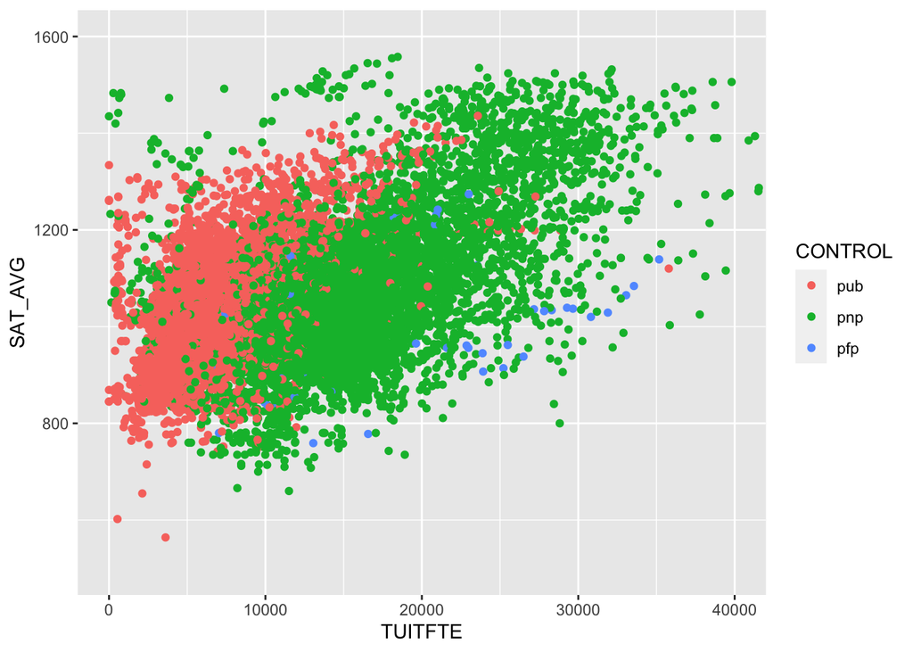

```r
#Plot
ggplot(data = scores.sub) +
  geom_point(aes(x = TUITFTE,
                 y = SAT_AVG,
                 group = CONTROL,
                 color = CONTROL)) +
  coord_cartesian(xlim = c(0, 40000), ylim = c(500, 1600))
```

Now tabulate the number of schools that have tuition per FTE over 20,000 and/or average SAT over 1200, grouped by ownership category. Your output should be sorted on the groupings you define, so the first row should be public, TUITFTE < 20,000 and SAT_AVG < 1200, and so on for 12 rows. See the Introduction vignette for data.table for insight on how to perform this operation. Hint: “sorted by” and “expressions in by”.

```r
scores.sub[,
           .N,
           .(CONTROL, TUITFTE>20000, SAT_AVG>1200)]
```

```
##     CONTROL TUITFTE SAT_AVG     N
##      <fctr>  <lgcl>  <lgcl> <int>
##  1:     pub   FALSE   FALSE  4207
##  2:     pnp   FALSE   FALSE  5648
##  3:     pnp    TRUE   FALSE   611
##  4:     pnp   FALSE    TRUE   411
##  5:     pub   FALSE    TRUE   437
##  6:     pnp    TRUE    TRUE   853
##  7:     pfp   FALSE   FALSE    61
##  8:     pfp    TRUE   FALSE    22
##  9:     pub    TRUE    TRUE    17
## 10:     pub    TRUE   FALSE    12
## 11:     pfp   FALSE    TRUE     2
## 12:     pfp    TRUE    TRUE     4
```

# Question 3 - subsets of data

Use data.table to obtain the tuition per FTE and average SAT for the two schools with the top average SAT within each ownership group. Hint: I performed this in two steps, first by ordering `scores.sub`, and then using “subset of data”. Make sure to avoid returning all of the columns…

```r
#ordering scores.sub by average SAT within each ownership group
p1 <- scores.sub[order(CONTROL, -SAT_AVG)]

#get the two schools with top average SAT within each ownership group
p1[, print(.SD[1:2]), by = CONTROL, .SDcols = c("UNITID", "INSTNM", "SAT_AVG", "CONTROL", "TUITFTE")]
```

```
##    UNITID                            INSTNM SAT_AVG CONTROL TUITFTE
##     <int>                            <char>   <num>  <fctr>   <num>
## 1: 170976  University of Michigan-Ann Arbor    1436     pub   23581
## 2: 110635 University of California-Berkeley    1422     pub   19498
##    UNITID                             INSTNM SAT_AVG CONTROL TUITFTE
##     <int>                             <char>   <num>  <fctr>   <num>
## 1: 110404 California Institute of Technology    1558     pnp   18456
## 2: 110404 California Institute of Technology    1555     pnp   18091
##    UNITID                          INSTNM SAT_AVG CONTROL TUITFTE
##     <int>                          <char>   <num>  <fctr>   <num>
## 1: 443410 DigiPen Institute of Technology    1274     pfp   22998
## 2: 443410 DigiPen Institute of Technology    1242     pfp   21020
```

```
## Empty data.table (0 rows and 1 cols): CONTROL
```

# Question 4 - MovieLens sparse dataset

As we mentioned in class, one common form of sparse data is when we have information about individuals and their interaction with a large set of items (e.g. movies, products, etc.). The interactions may be ratings or purchases. One publicly available dataset of movie ratings is *MovieLens*, which has a 1 MB download available here:

https://grouplens.org/datasets/movielens/

Download the `ml-latest-small.zip` dataset. Take a look at each of the CSV files. How many of the movies have the “Comedy” genre attached to them?

```r
#load the csv files
links <- fread("/Users/sophshan/Desktop/OneDrive - University of North Carolina at Chapel Hill/UNC/Spring 2024/BIOS 735/Homework Assignments/HW4/ml-latest-small/links.csv")
movies <- fread("/Users/sophshan/Desktop/OneDrive - University of North Carolina at Chapel Hill/UNC/Spring 2024/BIOS 735/Homework Assignments/HW4/ml-latest-small/movies.csv")
ratings <- fread("/Users/sophshan/Desktop/OneDrive - University of North Carolina at Chapel Hill/UNC/Spring 2024/BIOS 735/Homework Assignments/HW4/ml-latest-small/ratings.csv")
tags <- fread("/Users/sophshan/Desktop/OneDrive - University of North Carolina at Chapel Hill/UNC/Spring 2024/BIOS 735/Homework Assignments/HW4/ml-latest-small/tags.csv")
```

```r
#get all matches with "Comedy" in string
partial_matches <- grep("Comedy", movies$genres, value = TRUE)

length(partial_matches)
```

```
## [1] 3756
```

```r
#3756 movies have the "Comedy" genre attached to them.
```

Build a sparse matrix of the movies by users, and just put a 1 for if the user rated the movie (don’t actually record the value of the rating itself). You can do this by specifying `x=1`. In the abstract, this is a very large matrix, but this is because the user IDs go up to nearly 200,000. Remove the rows of the sparse matrix where there are no ratings to produce a sparse matrix that is roughly ~10,000 by ~600. Use `summary` to investigate the range, quartiles, etc. of number of movies rated by each user.

```r
#join together movies and users
together <- ratings %>%
  left_join(movies) %>%
  select(userId, movieId, rating)
#pivot from long to wide
together_wide <- dcast(together, movieId ~ userId, value.var = "rating",
                       fun.aggregate = function(x) { 1 }, fill = 0)
dim(together_wide)
```

```
## [1] 9724  611
```

```r
#make a sparse matrix (delete first column)
together_wide_sparse <- Matrix(as.matrix(together_wide[,-1, with = FALSE]),
                               sparse = TRUE)
together_wide_sparse[1:25, 1:25]
```

```
## 25 x 25 sparse Matrix of class "dgCMatrix"
```

```
##   [[ suppressing 25 column names '1', '2', '3' ... ]]
```

```
##
##  [1,] 1 . . . 1 . 1 . . . . . . . 1 . 1 1 1 . 1 . . . .
##  [2,] . . . . . 1 . 1 . . . . . . . . . 1 1 1 1 . . . .
##  [3,] 1 . . . . 1 . . . . . . . . . . . . 1 . . . . . .
##  [4,] . . . . . 1 . . . . . . . 1 . . . . . . . . . . .
##  [5,] . . . . . 1 . . . . . . . . . . . . . . . . . . .
##  [6,] 1 . . . . 1 . . . . 1 . . . . . . 1 . . . . 1 1 .
##  [7,] . . . . . 1 . . . . . . . 1 . . . . 1 . . . . . .
##  [8,] . . . . . 1 . . . . . . . . . . . . . 1 . . . . .
##  [9,] . . . . . . . . . . . . . . . . . . . . . . . . .
## [10,] . . . . . 1 . 1 . . 1 . . . . . . . 1 . 1 . . . .
## [11,] . . . . . 1 . 1 . . . . . . . . . . . . . . . . .
## [12,] . . . . . . . . . . . . . . . . . . 1 . . . . . .
## [13,] . . . . . 1 . . . . . . . . . . . . 1 1 . . . . .
## [14,] . . . . . . . . . . . . . . . . . . . . . . . . .
## [15,] . . . . . 1 . . . . . . . . . . . . 1 . . . . . .
## [16,] . . . . . 1 . . . . . . . . . . . 1 . . . . . . .
## [17,] . . . . . 1 . . . . . . . . . . . . . . . . . . .
## [18,] . . . . . . . . . . . . . . . . . . . . . . . . .
## [19,] . . . . . 1 . . . . . . . 1 . . . . 1 . 1 . . . .
## [20,] . . . . . . . . . . . . . . . . . . . . . . . . .
## [21,] . . . 1 1 1 . 1 . . . . . . . . . . . . . . . . .
## [22,] . . . . . 1 . . . . . . . . . . . . . . . . . . .
## [23,] . . . . . . . . . . . . . . . . . . . . . . . . .
## [24,] . . . . . 1 . . . . . . . . . . . . . . . . . . .
## [25,] . . . . . 1 . . . . . . . 1 . . . . . . . . . . .
```

```r
#get the total number of movies rated by each user
number_of_movies <- colSums(together_wide_sparse)
summary(number_of_movies)
```

```
##    Min. 1st Qu.  Median    Mean 3rd Qu.    Max.
##    20.0    35.0    70.5   165.3   168.0  2698.0
```

There are multiple ways to compute the SVD of a sparse matrix. If after manipulating the matrix in its sparse form, it is not too large (as in this case), one can just run `svd` which will coerce the matrix into a dense one. Or there are special functions in packages which are designed to compute (potentially sparse) SVD solutions on sparse matrices. Two such functions are `sparsesvd::sparsesvd` and `irlba::ssvd`. You can choose any of these three methods, in either case you should specify to return only 3 left singular vectors (`nu=3`, `rank=3`, or `k=3`, respectively). For `ssvd` in the irlba package, you should specify that the number of nonzero components in the right singular vectors should be all (the number of rows of x), which will give a warning that you should ignore. All of these methods will produce roughly the same decomposition, with arbitrary sign changes on the singular vectors. The sparse versions are about 1000 times faster, as they do not coerce the matrix into a dense version.

```r
#install sparsesvd package
#install.packages("sparsesvd")

library("sparsesvd")
```

Compute the SVD of the matrix using one of the methods above.

```r
#compute SVD
together_SVD <- sparsesvd::sparsesvd(together_wide_sparse, rank = 3)
```

Plot the columns of the U matrix against each other: 1 vs 2, 2 vs 3, 1 vs 3. Note that column 1 and 3 are correlated, with a long tail of movies.

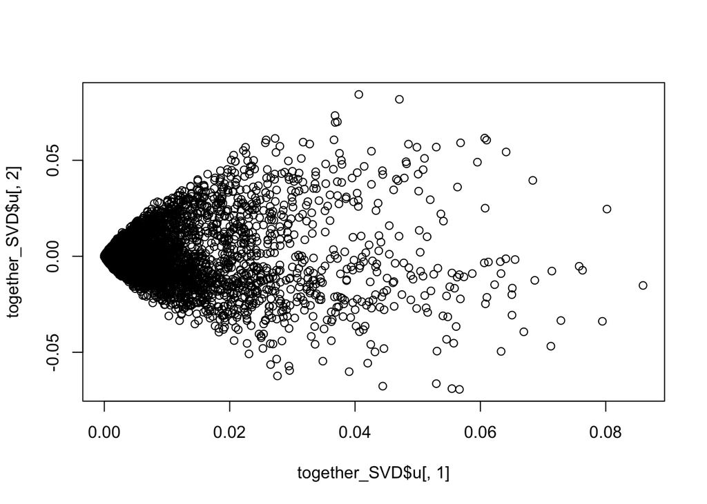

```r
#1 vs 2
plot(together_SVD$u[,1], together_SVD$u[, 2])
```

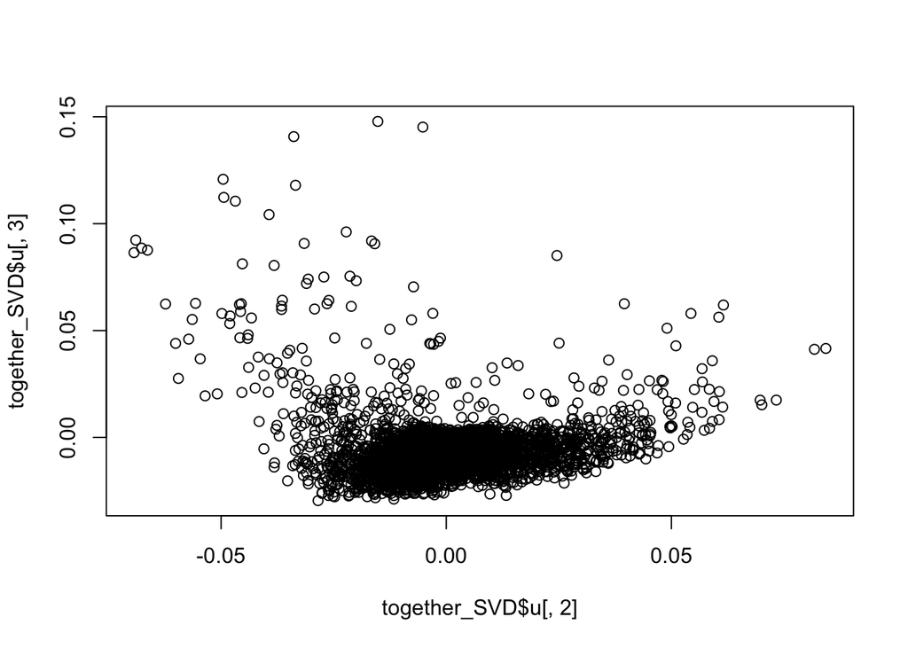

```r
#2 vs 3
plot(together_SVD$u[,2], together_SVD$u[, 3])
```

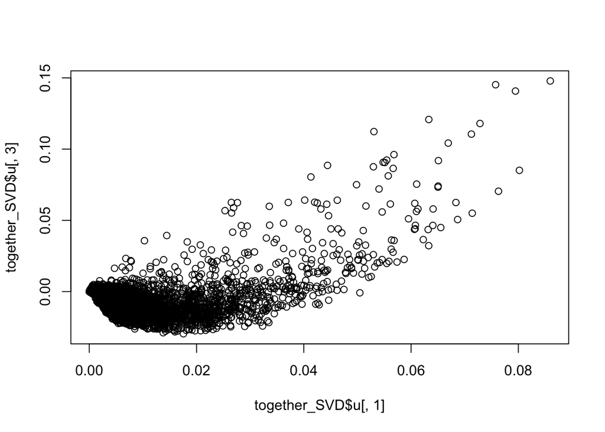

```r
#1 vs 3
plot(together_SVD$u[,1], together_SVD$u[, 3])
```

Investigate the names of these movies. What property can you infer about the top 6 movies in the tail w.r.t. column 1 and 3?

```r
#subset the list of movies
movies_subset <- movies %>%
  filter(movieId %in% ratings$movieId)

#top 6 in the tail for column 1
c1_top6 <- order(together_SVD$u[,1], decreasing = TRUE)[1:6]

movies_subset[c1_top6]
```

```
##    movieId                                     title
##      <int>                                    <char>
## 1:     356                       Forrest Gump (1994)
## 2:    2571                        Matrix, The (1999)
## 3:     296                       Pulp Fiction (1994)
## 4:     260 Star Wars: Episode IV - A New Hope (1977)
## 5:     318          Shawshank Redemption, The (1994)
## 6:     593          Silence of the Lambs, The (1991)
##                         genres
##                         <char>
## 1:    Comedy|Drama|Romance|War
## 2:      Action|Sci-Fi|Thriller
## 3: Comedy|Crime|Drama|Thriller
## 4:     Action|Adventure|Sci-Fi
## 5:                 Crime|Drama
## 6:       Crime|Horror|Thriller
```

```r
#top 6 in the tail for column 3
c3_top6 <- order(together_SVD$u[,3], decreasing = TRUE)[1:6]

movies_subset[c3_top6]
```

```
##    movieId                            title                      genres
##      <int>                           <char>                      <char>
## 1:     356              Forrest Gump (1994)    Comedy|Drama|Romance|War
## 2:     318 Shawshank Redemption, The (1994)                 Crime|Drama
## 3:     296              Pulp Fiction (1994) Comedy|Crime|Drama|Thriller
## 4:     110                Braveheart (1995)            Action|Drama|War
## 5:     593 Silence of the Lambs, The (1991)       Crime|Horror|Thriller
## 6:     150                 Apollo 13 (1995)        Adventure|Drama|IMAX
```

```r
#The top movies are the most popular movies. These movies
#are still watched by audiences to this day.
```

Now look at the extremes of column 2 of U. What difference can you tell about the movies, between the smallest values and the largest values in column 2?

```r
#top 6 in the tail for column 2
c2_top6 <- order(together_SVD$u[,2], decreasing = TRUE)[1:6]

movies_subset[c2_top6]
```

```
##    movieId                                                 title
##      <int>                                                <char>
## 1:   79132                                      Inception (2010)
## 2:   58559                               Dark Knight, The (2008)
## 3:   68954                                             Up (2009)
## 4:   72998                                         Avatar (2009)
## 5:   59315                                       Iron Man (2008)
## 6:    7153 Lord of the Rings: The Return of the King, The (2003)
##                                             genres
##                                             <char>
## 1: Action|Crime|Drama|Mystery|Sci-Fi|Thriller|IMAX
## 2:                         Action|Crime|Drama|IMAX
## 3:              Adventure|Animation|Children|Drama
## 4:                    Action|Adventure|Sci-Fi|IMAX
## 5:                         Action|Adventure|Sci-Fi
## 6:                  Action|Adventure|Drama|Fantasy
```

```r
#bottom 6 for column 2
c2_bottom6 <- order(together_SVD$u[,2], decreasing = FALSE)[1:6]

movies_subset[c2_bottom6]
```

```
##    movieId                           title
##      <int>                          <char>
## 1:     592                   Batman (1989)
## 2:     457            Fugitive, The (1993)
## 3:     590       Dances with Wolves (1990)
## 4:     380                True Lies (1994)
## 5:     349 Clear and Present Danger (1994)
## 6:     587                    Ghost (1990)
##                                      genres
##                                      <char>
## 1:                    Action|Crime|Thriller
## 2:                                 Thriller
## 3:                  Adventure|Drama|Western
## 4: Action|Adventure|Comedy|Romance|Thriller
## 5:              Action|Crime|Drama|Thriller
## 6:    Comedy|Drama|Fantasy|Romance|Thriller
```

```r
#The largest values are more recent popular movies while
#the smallest values are the older movies.
```

Hint: there are a few movies which are in the `movies.csv` file, but are not in the `ratings.csv` file. I recommend to subset the list of movies first, which will help with this problem.